# FPP - Ch. 7 Exercises

##### Dan Hong | dnaeye@gmail.com

The following are my answers to the exercises in the excellent book [Forecasting: Principles & Practice](https://otexts.org/fpp2/) by Rob J Hyndman and George Athanasopoulos.

#### 1. Consider the `pigs` series — the number of pigs slaughtered in Victoria each month.

**1a.** Use the `ses()` function in R to find the optimal values of $\alpha$ and $l_0$, and generate forecasts for the next four months.

```r
fcast.pigs <- ses(pigs, h=4)
summary(fcast.pigs)
```

```
Forecast method: Simple exponential smoothing

Model Information:
Simple exponential smoothing

Call:
 ses(y = pigs, h = 4)

  Smoothing parameters:
    alpha = 0.2971

  Initial states:
    l = 77260.0561

  sigma:  10308.58

     AIC     AICc      BIC
4462.955 4463.086 4472.665

Error measures:
                   ME    RMSE      MAE       MPE     MAPE      MASE
Training set 385.8721 10253.6 7961.383 -0.922652 9.274016 0.7966249
                   ACF1
Training set 0.01282239

Forecasts:
         Point Forecast    Lo 80    Hi 80    Lo 95    Hi 95
Sep 1995       98816.41 85605.43 112027.4 78611.97 119020.8
Oct 1995       98816.41 85034.52 112598.3 77738.83 119894.0
Nov 1995       98816.41 84486.34 113146.5 76900.46 120732.4
Dec 1995       98816.41 83958.37 113674.4 76092.99 121539.8
```

The optimal value for $\alpha$ is 0.2971 and for $l_0$ it’s 77260.0561. The forecasts for the next 4 months are all 98816.41.

**1b.** Compute a 95% prediction interval for the first forecast using $\hat{y}$ $\pm$ 1.96$s$ where $s$ is the standard deviation of the residuals. Compare your interval with the interval produced by R.

As the forecast is 98816.41 and $\sigma$ is 10308.58, the 95% prediction interval can be calculated as 98816.41 - 1.96 * 10308.58 = 78611 and 98816.41 + 1.96 * 10308.58 = 119021, which are exactly what are listed in the model’s summary.

#### 2. Write your own function to implement simple exponential smoothing. The function should take arguments `y` (the time series), `alpha` (the smoothing parameter $\alpha$) and `level` (the initial level $l_0$). It should return the forecast of the next observation in the series. Does it give the same forecast as `ses()`?

```r
custom_ses <- function(ts, alpha, l0) {
  N <- length(ts)
  y_hat = c(l0, 0 * (2:N))
  for (j in 1:(N-1)) {
    new <- alpha * ts[j] + (1 - alpha) * y_hat[j]
    y_hat[j+1] = new
  }
  return(y_hat)
}
ts <- pigs
tail(custom_ses(ts, 0.2971, 77260.0561),1)
```

```
[1] 98102.32
```

Using the $\alpha$ and $l_0$ found by the `ses` function, my custom SES function - which is an implementation of the [weighted average form](https://otexts.org/fpp2/ses.html) - returned roughly the same answer.

#### 3. Modify your function from the previous exercise to return the sum of squared errors rather than the forecast of the next observation. Then use the `optim()` function to find the optimal values of $\alpha$ and $l_0$. Do you get the same values as the `ses()` function?

```r
custom_rss <- function(par, ts) {
  # ensure alpha parameter is bounded between 0 and 1
  alpha = plogis(par[1])
  l0 = par[2]

  N = length(ts)
  fit = custom_ses(ts, alpha, l0)
  res = ts - fit

  out = sum(res^2)/(N-1)
  return(out)
}
```

```r
# optim-based estimates; alpha is first parameter, level is second parameter
est = optim(par = c(0.1, 5000), fn = custom_rss, ts=ts)
alpha = plogis(est$par[1])
l0 = est$par[2]
# ses estimates
ses.fit <- ses(ts)
cbind(ses = ses.fit$model$par, custom = c(alpha, l0))
```

```
               ses       custom
alpha 2.971488e-01 2.972525e-01
l     7.726006e+04 7.725105e+04
```

As shown in the table above, the optimal $\alpha$ and $l_0$ values from my custom SES model and the `ses` function were very similar.

For bonus points, here is a plot comparing the fitted values of the two SES models.

```r
# fit ses model to data
fit = custom_ses(ts, alpha=alpha, l0=l0)
# Plots
plot(1:length(ts), ts, type = "l", lwd = 1, col = 8)
points(1:length(ts), ts, pch = 16, col = 8, cex = 0.5)
```

```r
lines(1:length(ts), ses.fit$fitted, col = 2, type = "l", lwd = 2)
lines(1:length(ts), fit, col = 3, type = "l", lty = 2,  lwd = 2)
```

[figure not shown]

```r
legend("bottomright", legend = c("Data", "ses", "custom"), col = c(8, 2, 3),
       lty = c(1,1,2), lwd = 2)
```

#### 5. Data set `books` contains the daily sales of paperback and hardcover books at the same store. The task is to forecast the next four days’ sales for paperback and hardcover books.

**5a.** Plot the series and discuss the main features of the data.

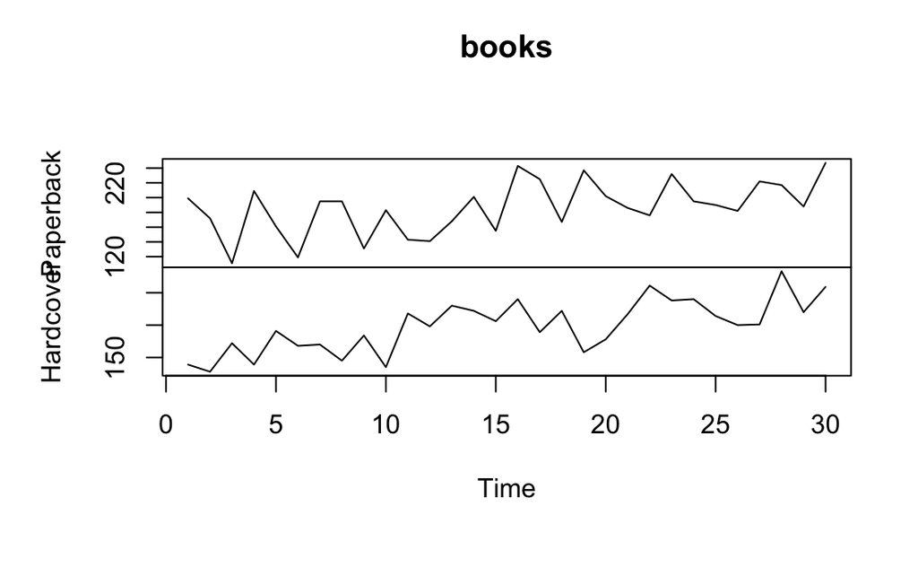

```r
plot(books)
```

Although both time series look random, there seems to be a general upward trend.

**5b.** Use the `ses()` function to forecast each series, and plot the forecasts.

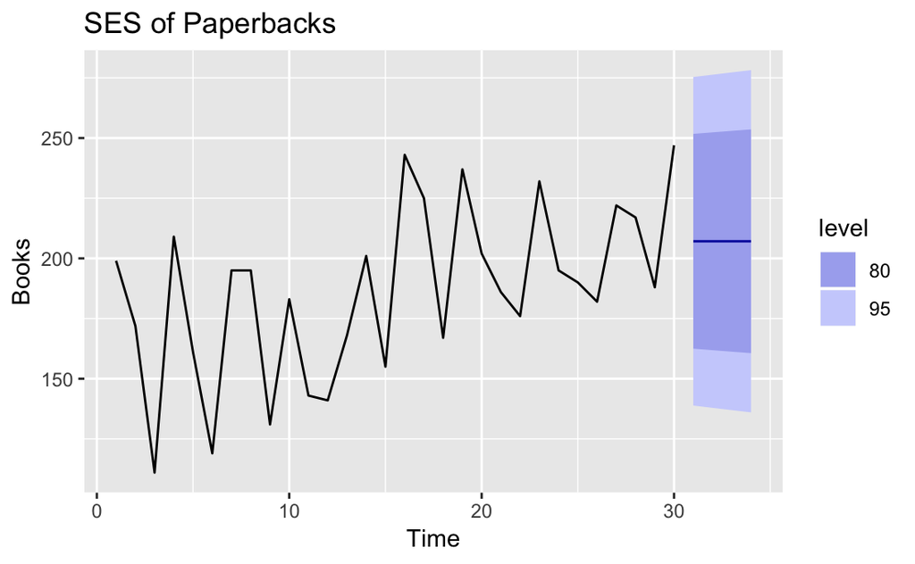

```r
pb <- books[,1]
fcast.pb <- ses(pb, h=4)
autoplot(fcast.pb) + ggtitle("SES of Paperbacks") + ylab("Books")
```

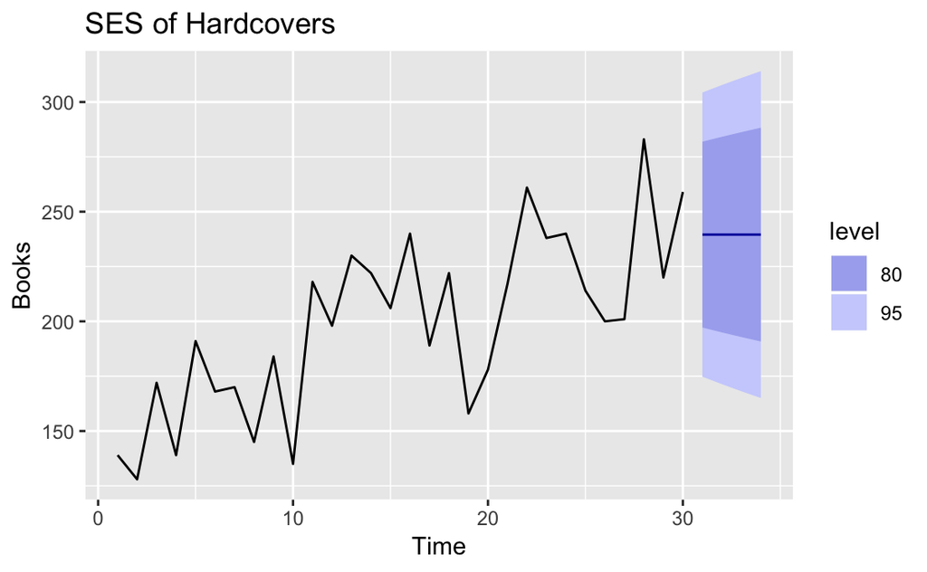

```r
hc <- books[,2]
fcast.hc <- ses(hc, h=4)
autoplot(fcast.hc) + ggtitle("SES of Hardcovers") + ylab("Books")
```

**5c.** Compute the RMSE values for the training data in each case.

```r
acc.pb <- accuracy(fcast.pb)
acc.pb
```

```
                   ME     RMSE     MAE       MPE     MAPE      MASE
Training set 7.175981 33.63769 27.8431 0.4736071 15.57784 0.7021303
                   ACF1
Training set -0.2117522
```

```r
acc.hc <- accuracy(fcast.hc)
acc.hc
```

```
                   ME     RMSE      MAE      MPE     MAPE      MASE
Training set 9.166735 31.93101 26.77319 2.636189 13.39487 0.7987887
                   ACF1
Training set -0.1417763
```

The RMSE of the `paperbacks` time series was 33.64, while that of the `hardcovers` time series was 31.93.

#### 6a. Now apply Holt’s linear method to the paperback and hardback series and compute four-day forecasts in each case.

```r
pb7 <- ts(pb, frequency=7)
fcast.pb7 <- hw(pb7, h=4)
fcast.pb7
```

```
         Point Forecast    Lo 80    Hi 80    Lo 95    Hi 95
5.285714       219.3449 170.7952 267.8947 145.0945 293.5954
5.428571       200.8921 152.3424 249.4419 126.6417 275.1426
5.571429       206.6405 158.0907 255.1903 132.3900 280.8910
5.714286       203.0517 154.5019 251.6015 128.8012 277.3022
```

```r
hc7 <- ts(hc, frequency=7)
fcast.hc7 <- hw(hc7, h=4)
fcast.hc7
```

```
         Point Forecast    Lo 80    Hi 80    Lo 95    Hi 95
5.285714       219.7170 174.4902 264.9438 150.5486 288.8855
5.428571       236.3420 190.9795 281.7046 166.9661 305.7180
5.571429       217.0727 171.4123 262.7331 147.2412 286.9043
5.714286       217.7323 171.5523 263.9124 147.1061 288.3586
```

**6b.** Compare the RMSE measures of Holt’s method for the two series to those of simple exponential smoothing in the previous question. (Remember that Holt’s method is using one more parameter than SES.) Discuss the merits of the two forecasting methods for these data sets.

```r
acc.pb7 <- accuracy(fcast.pb7)
acc.pb7
```

```
                    ME     RMSE     MAE       MPE     MAPE      MASE
Training set -3.603653 30.14861 24.4062 -5.259677 14.75415 0.6690616
                   ACF1
Training set -0.1478474
```

```r
acc.hc7 <- accuracy(fcast.hc7)
acc.hc7
```

```
                    ME     RMSE      MAE       MPE     MAPE      MASE
Training set -5.564707 28.08511 24.01086 -4.733864 13.14081 0.6275567
                  ACF1
Training set 0.0461953
```

The RSME of the Holt-Winters forecasts of the `paperback` series was 30.15 vs. 33.64 for the SES model. The HW forecast model of the `hardcover` series was 28.09 vs. 31.93 for the SES model.

The Holt-Winters models for both time series were slightly better than the SES models, which makes sense, as the HW models took 7-day seasonality into account.

**6c.** Compare the forecasts for the two series using both methods. Which do you think is best?

```r
fcast.pb
```

```
   Point Forecast    Lo 80    Hi 80    Lo 95    Hi 95
31       207.1097 162.4882 251.7311 138.8670 275.3523
32       207.1097 161.8589 252.3604 137.9046 276.3147
33       207.1097 161.2382 252.9811 136.9554 277.2639
34       207.1097 160.6259 253.5935 136.0188 278.2005
```

```r
fcast.pb7
```

```
         Point Forecast    Lo 80    Hi 80    Lo 95    Hi 95
5.285714       219.3449 170.7952 267.8947 145.0945 293.5954
5.428571       200.8921 152.3424 249.4419 126.6417 275.1426
5.571429       206.6405 158.0907 255.1903 132.3900 280.8910
5.714286       203.0517 154.5019 251.6015 128.8012 277.3022
```

```r
fcast.hc
```

```
   Point Forecast    Lo 80    Hi 80    Lo 95    Hi 95
31       239.5601 197.2026 281.9176 174.7799 304.3403
32       239.5601 194.9788 284.1414 171.3788 307.7414
33       239.5601 192.8607 286.2595 168.1396 310.9806
34       239.5601 190.8347 288.2855 165.0410 314.0792
```

```r
fcast.hc7
```

```
         Point Forecast    Lo 80    Hi 80    Lo 95    Hi 95
5.285714       219.7170 174.4902 264.9438 150.5486 288.8855
5.428571       236.3420 190.9795 281.7046 166.9661 305.7180
5.571429       217.0727 171.4123 262.7331 147.2412 286.9043
5.714286       217.7323 171.5523 263.9124 147.1061 288.3586
```

Looking at the actual forecasts of both types of models - SES and Holt-Winters - the latter produced better forecasts because it tried to emulate more micro trends in the data, whereas SES was simply a naive type of model. The lower RMSE measures support this assessment.

**6d.** Calculate a 95% prediction interval for the first forecast for each series, using the RMSE values and assuming normal errors. Compare your intervals with those produced using `ses` and `holt`.

```r
pb_rmse_lo <- fcast.pb$mean[1] - 1.96 * acc.pb[2]
pb_rmse_hi <- fcast.pb$mean[1] + 1.96 * acc.pb[2]
pb_rmse <- c(pb_rmse_lo, pb_rmse_hi)
pb_ses_lo <- fcast.pb$lower[,2][1]
pb_ses_hi <- fcast.pb$upper[,2][1]
pb_ses <- c(pb_ses_lo, pb_ses_hi)
pb7_rmse_lo <- fcast.pb7$mean[1] - 1.96 * acc.pb7[2]
pb7_rmse_hi <- fcast.pb7$mean[1] + 1.96 * acc.pb7[2]
pb7_rmse <- c(pb7_rmse_lo, pb7_rmse_hi)
pb7_hw_lo <- fcast.pb7$lower[,2][1]
pb7_hw_hi <- fcast.pb7$upper[,2][1]
pb7_hw <- c(pb7_hw_lo, pb7_hw_hi)
pb_df <- t(data.frame(pb_rmse, pb_ses, pb7_rmse, pb7_hw))
rownames(pb_df) <- c("SES-RMSE","SES","HW-RMSE","HW")
colnames(pb_df) <- c("Lo 95","Hi 95")
```

#### 7. For this exercise use data set `eggs`, the price of a dozen eggs in the United States from 1900–1993. Experiment with the various options in the `holt()` function to see how much the forecasts change with damped trend, or with a Box-Cox transformation. Try to develop an intuition of what each argument is doing to the forecasts.

[Hint: use `h=100` when calling `holt()` so you can clearly see the differences between the various options when plotting the forecasts.]

Which model gives the best RMSE?

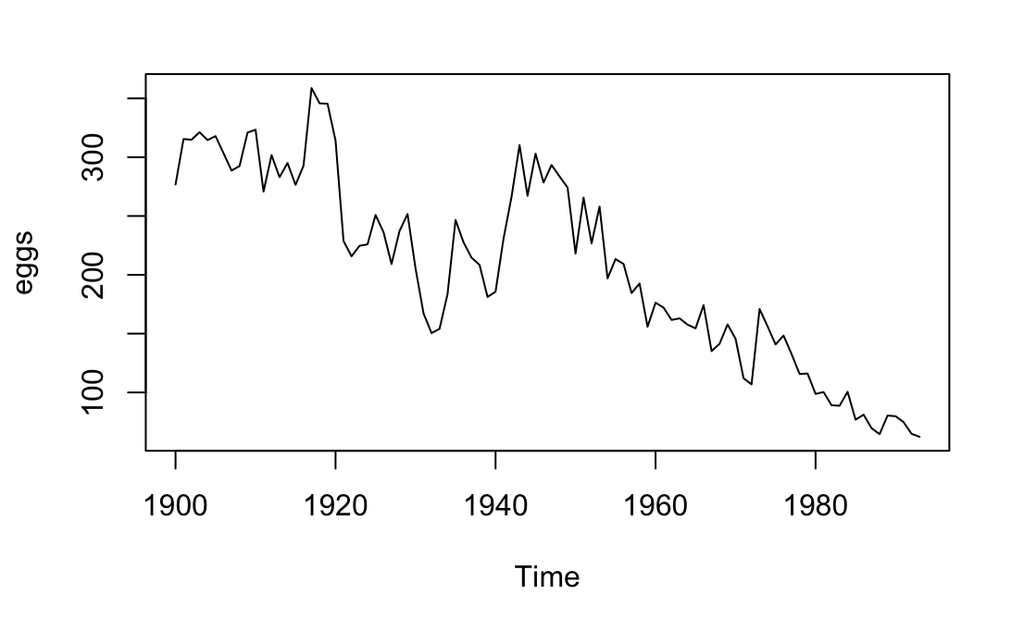

```r
plot(eggs)
```

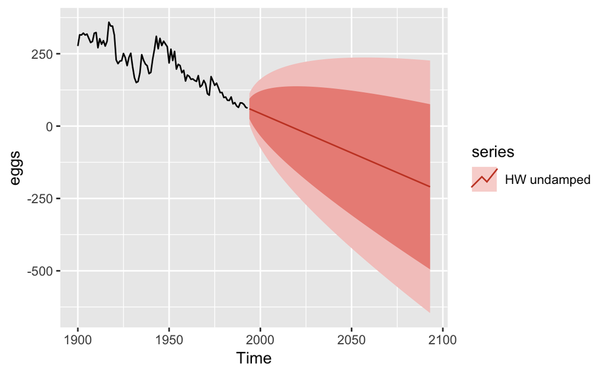

```r
# basic model (undamped, additive)
fcast.h <- holt(eggs, damped = FALSE, seasonal="additive", h=100)
autoplot(eggs) + autolayer(fcast.h, series="HW undamped")
```

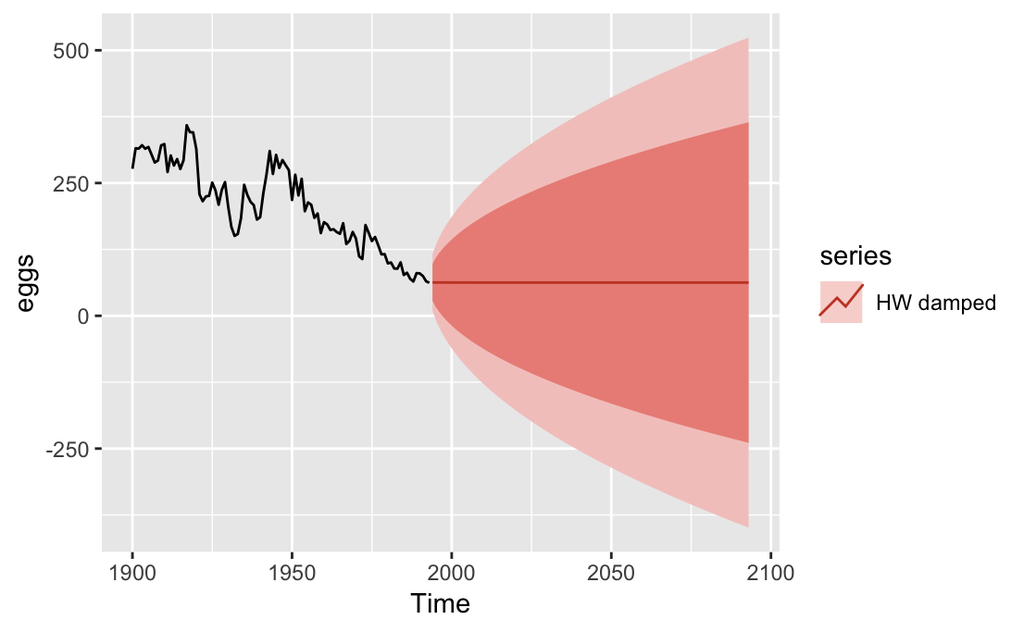

```r
# damped model
fcast.hd <- holt(eggs, damped = TRUE, seasonal="additive", h=100)
autoplot(eggs) + autolayer(fcast.hd, series="HW damped")
```

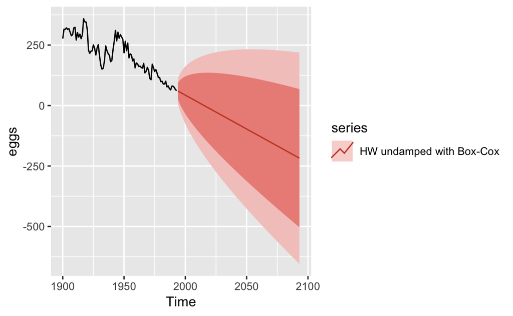

```r
# Box-Cox transformed undamped model
fcast.hbu <- holt(eggs, damped = FALSE, seasonal="additive", lambda=TRUE, h=100)
autoplot(eggs) + autolayer(fcast.hbu, series="HW undamped with Box-Cox")
```

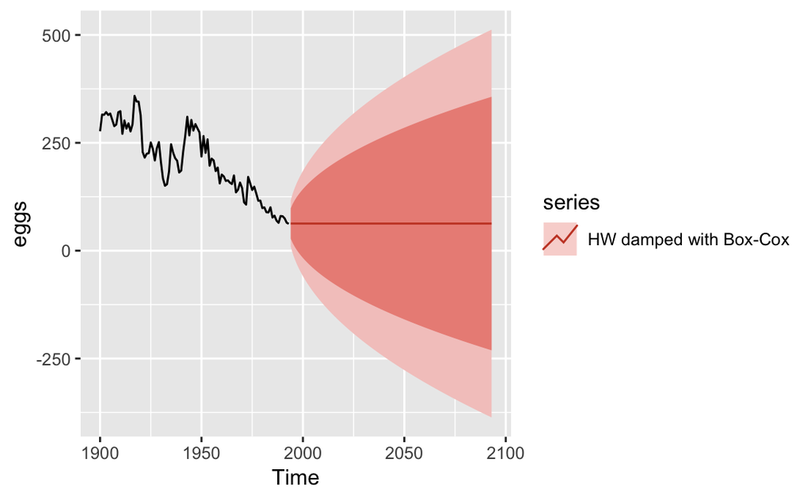

```r
# Box-Cox transformed damped model
fcast.hbd <- holt(eggs, damped = TRUE, seasonal="additive", lambda=TRUE, h=100)
autoplot(eggs) + autolayer(fcast.hbd, series="HW damped with Box-Cox")
```

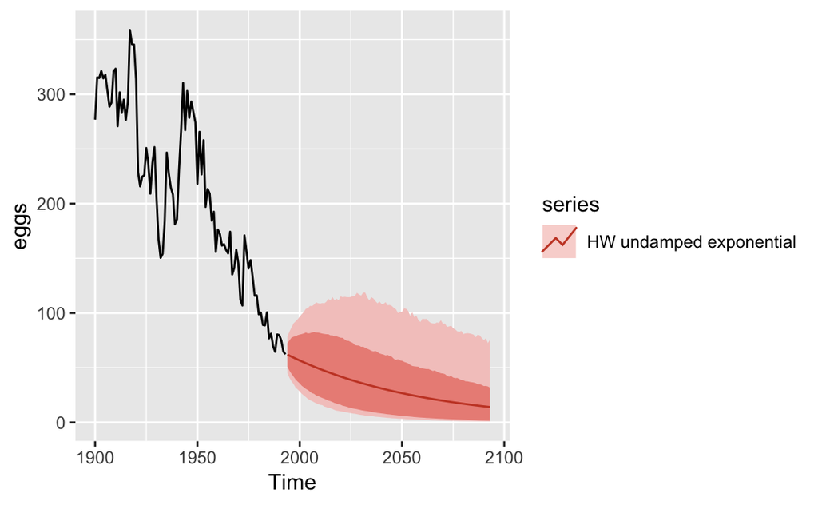

```r
# undamped exponential model
fcast.he <- holt(eggs, damped = FALSE, seasonal="additive", exponential = TRUE, h=100)
autoplot(eggs) + autolayer(fcast.he, series="HW undamped exponential")
```

```r
acc.h <- round(accuracy(fcast.h),3)
acc.hd <- round(accuracy(fcast.hd),3)
acc.hbu <- round(accuracy(fcast.hbu),3)
acc.hbd <- round(accuracy(fcast.hbd),3)
acc.he <- round(accuracy(fcast.he),3)
h <- c("Holt undamped",acc.h[2])
hd <- c("Holt damped", acc.hd[2])
hbu <- c("Holt undamped with Box-Cox", acc.hbu[2])
hbd <- c("Holt damped with Box-Cox", acc.hbd[2])
he <- c("Holt undamped exponential", acc.he[2])
holt_rmse <- data.frame(t(data.frame(h, hd, hbu, hbd, he)))
colnames(holt_rmse) <- c("Model", "RMSE")
holt_rmse
```

```
                         Model   RMSE
h                Holt undamped 26.582
hd                 Holt damped  26.54
hbu Holt undamped with Box-Cox 26.555
hbd   Holt damped with Box-Cox 26.734
he   Holt undamped exponential 26.498
```

The model with the lowest RMSE was actually the undamped exponential.

#### 8. Recall your retail time series data (from Exercise 3 in Section [2.10](https://otexts.org/fpp2/graphics-exercises.html#graphics-exercises)).

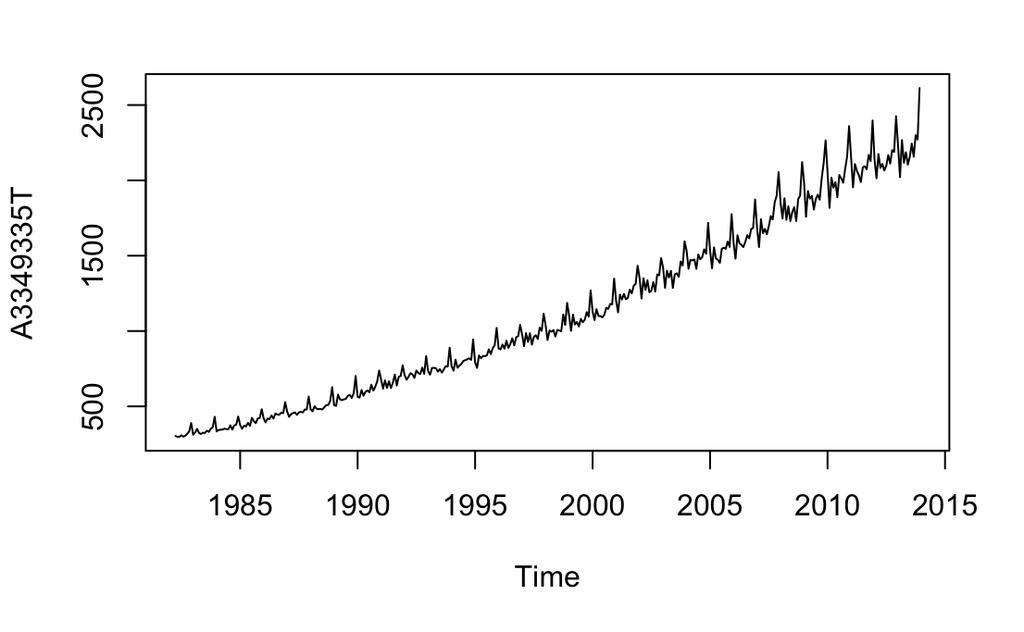

```r
retaildata <- readxl::read_excel("retail.xlsx", skip=1)
retail <- ts(retaildata[,"A3349335T"], frequency=12, start=c(1982,4))
plot(retail)
```

**8a.** Why is multiplicative seasonality necessary for this series?

It’s necessary because the seasonality variance is increasing.

**8b.** Apply Holt-Winters’ multiplicative method to the data. Experiment with making the trend damped.

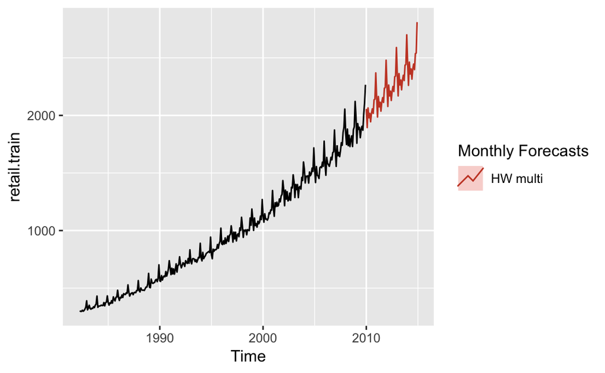

```r
# split retail data into training and test sets
retail.train <- window(retail, end=c(2009,12))
retail.test <- window(retail, start=c(2010,1))
hw.mult <- hw(retail.train, seasonal="multiplicative", h=60)
autoplot(retail.train) + autolayer(hw.mult, series="HW multi", PI=FALSE) + guides(color=guide_legend(title="Monthly Forecasts"))
```

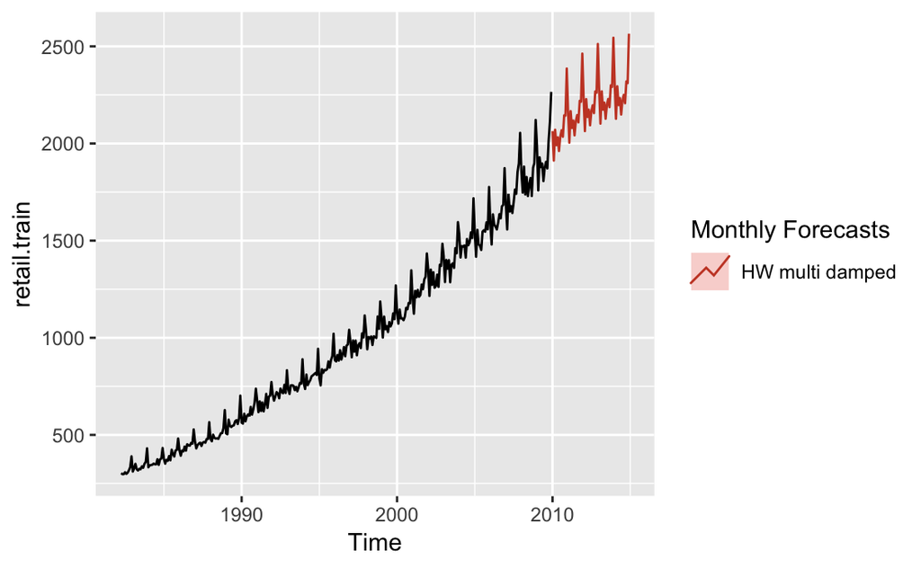

```r
hw.damp <- hw(retail.train, seasonal="multiplicative", damped=TRUE, h=60)
autoplot(retail.train) + autolayer(hw.damp, series="HW multi damped", PI=FALSE) + guides(color=guide_legend(title="Monthly Forecasts"))
```

**8c.** Compare the RMSE of the one-step forecasts from the two methods. Which do you prefer?

```r
acc.mult <- accuracy(hw.mult, retail.test)
acc.damp <- accuracy(hw.damp, retail.test)
acc.mult
```

```
                     ME     RMSE      MAE        MPE     MAPE      MASE
Training set   2.550349 24.59270 17.94514  0.2224846 2.004664 0.2954425
Test set     -78.915045 93.05184 80.40057 -3.6713081 3.741994 1.3236868
                    ACF1 Theil's U
Training set -0.05715437        NA
Test set      0.66706936  0.665371
```

```r
acc.damp
```

```
                     ME     RMSE      MAE        MPE     MAPE      MASE
Training set   3.834903 24.59764 18.39526  0.3376469 2.159445 0.3028531
Test set     -42.711661 53.24147 46.92087 -2.0576850 2.228693 0.7724888
                   ACF1 Theil's U
Training set -0.1295940        NA
Test set      0.0632922 0.3897373
```

The training RMSE of the undamped and damped multiplicative Holt-Winters methods were quite similar, but on the test set, the multiplicative-damped method performed much better, with an RMSE of 53.2414699 vs. 93.0518419 from the undamped method.

**8d.** Check that the residuals from the best method look like white noise.

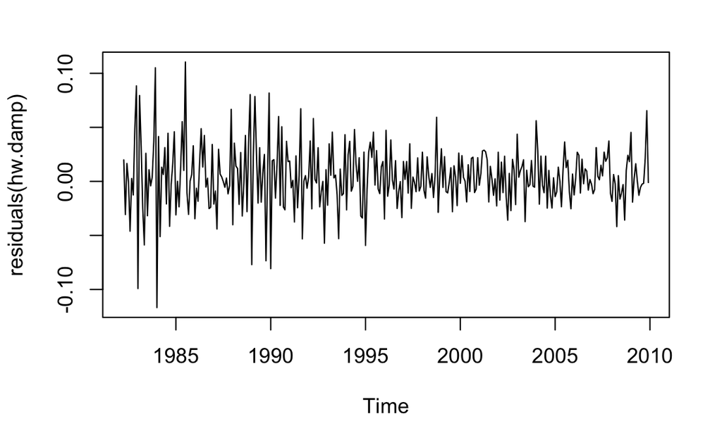

```r
plot(residuals(hw.damp))
```

There doesn’t seem to be any obvious patterns in the residuals plot, so the series can be considered as white noise.

**8e.** Now find the test set RMSE, while training the model to the end of 2010. Can you beat the seasonal naïve approach from Exercise 8 in Section [3.7](https://otexts.org/fpp2/toolbox-exercises.html#toolbox-exercises)?

```r
retail.train <- window(retail, frequency=12, end=c(2010,12))
retail.test <- window(retail, start=c(2011,1))
retail.hw <- hw(retail.train, seasonal="multiplicative", damped=TRUE, h=36)
retail.snaive <- snaive(retail.train, h=36)
acc.hw <- data.frame(accuracy(retail.hw, retail.test))
acc.snaive <- data.frame(accuracy(retail.snaive, retail.test))
acc.hw
```

```
                     ME     RMSE      MAE       MPE     MAPE      MASE
Training set   4.089724 25.68057 18.92510  0.371369 2.057716 0.3068053
Test set     -23.699364 39.60879 31.62906 -1.109011 1.448777 0.5127563
                    ACF1 Theil.s.U
Training set -0.05009924        NA
Test set     -0.05576411 0.2844991
```

```r
acc.snaive
```

```
                    ME      RMSE       MAE      MPE     MAPE     MASE
Training set  61.56787  72.20702  61.68438 6.388722 6.404105 1.000000
Test set     129.52500 145.46662 131.24722 5.988193 6.069098 2.127722
                  ACF1 Theil.s.U
Training set 0.6018274        NA
Test set     0.4067838  1.058244
```

The RMSE of the Holt-Winters damped multiplicative method of 39.6087901 beat that of the seasonal naive method, which was 145.4666199.

#### 9. For the same retail data, try an STL decomposition applied to the Box-Cox transformed series, followed by ETS on the seasonally adjusted data. How does that compare with your best previous forecasts on the test set?

```r
lambda <- BoxCox.lambda(retail.train)
retail.bc <- BoxCox(retail.train, lambda)
retail.stl <- stl(retail.bc[,1], s.window="periodic", t.window=13)
retail.bt <- retail.train - retail.stl$time.series[,1]
retail.ets <- ets(retail.bt)
fc.ets <- forecast(retail.ets, h=36)
acc.ets <- data.frame(accuracy(fc.ets, retail.test))
acc.ets
```

```
                     ME     RMSE      MAE        MPE     MAPE      MASE
Training set   2.166952 25.18541 18.12869  0.1675724 1.935027 0.2938944
Test set     -70.752110 83.29678 72.52333 -3.2439677 3.327156 1.1757162
                   ACF1 Theil.s.U
Training set 0.01776221        NA
Test set     0.52272485 0.6010186
```

#### 10. For this exercise use data set `ukcars`, the quarterly UK passenger vehicle production data from 1977Q1–2005Q1.

**10a.** Plot the data and describe the main features of the series.

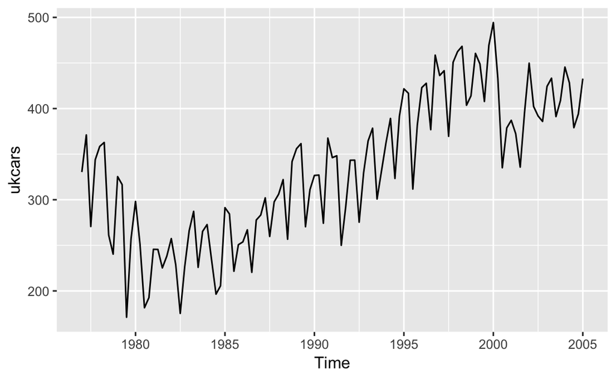

```r
autoplot(ukcars)
```

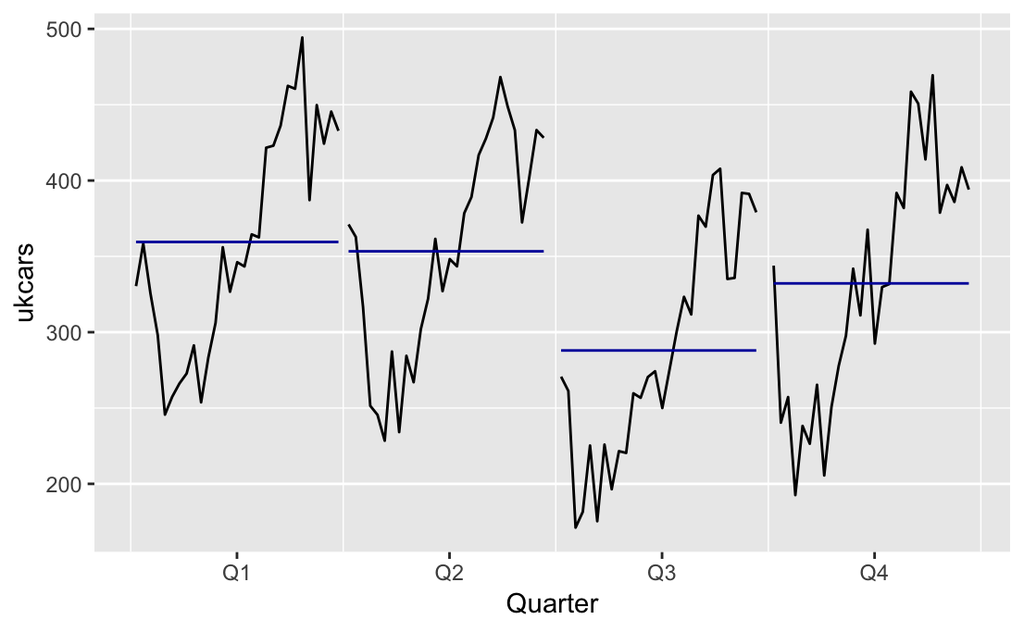

```r
ggsubseriesplot(ukcars)
```

After a negative trend for the first few years, the data enjoyed a long positive trend until 2000, when it experienced a huge drop. In addition, there is a quarterly seasonality.

**10b.** Decompose the series using STL and obtain the seasonally adjusted data.

```r
ukcars.stl <- stl(ukcars, s.window = "periodic")
ukcars.sa <- seasadj(ukcars.stl)
#ukcars.sa <- ukcars - ukcars.stl$time.series[,1]
```

**10c.** Forecast the next two years of the series using an additive damped trend method applied to the seasonally adjusted data. (This can be done in one step using `stlf()` with arguments `etsmodel="AAN"`, `damped=TRUE`.)

```r
ukcars.stlf <- stlf(ukcars.sa, etsmodel="AAN", damped=TRUE, h=8)
```

**10d.** Forecast the next two years of the series using Holt’s linear method applied to the seasonally adjusted data (as before but with `damped=FALSE`).

```r
ukcars.holt <- holt(ukcars.sa, h=8)
```

**10e.** Now use `ets()` to choose a seasonal model for the data.

```r
ukcars.ets <- ets(ukcars.sa)
```

**10f.** Compare the RMSE of the ETS model with the RMSE of the models you obtained using STL decompositions. Which gives the better in-sample fits?

```r
acc.stlf <- data.frame(accuracy(ukcars.stlf))
acc.stlf
```

```
                   ME     RMSE      MAE        MPE     MAPE     MASE
Training set 1.551267 23.32113 18.48987 0.07788374 5.952653 0.602576
                   ACF1
Training set 0.02262669
```

```r
acc.holt <- data.frame(accuracy(ukcars.holt))
acc.holt
```

```
                    ME     RMSE      MAE       MPE     MAPE    MASE
Training set -0.311188 25.26041 20.10954 -0.638754 6.490918 0.65536
                   ACF1
Training set 0.03183994
```

```r
acc.ets <- data.frame(accuracy(ukcars.ets))
acc.ets
```

```
                   ME     RMSE      MAE       MPE     MAPE      MASE
Training set 1.259928 25.22788 20.21952 -0.138332 6.508422 0.6589443
                   ACF1
Training set 0.02636798
```

The model with the lowest and best RMSE was the STL model with 23.3211329, which bested the 25 range of the Holt linear and ETS models.

**10g.** Compare the forecasts from the three approaches? Which seems most reasonable?

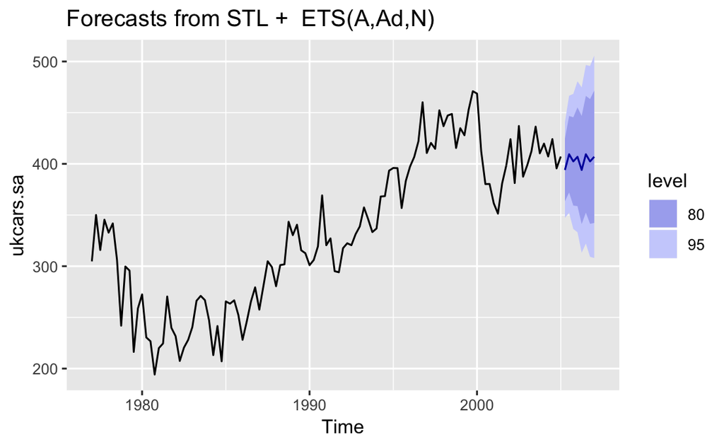

```r
autoplot(ukcars.stlf)
```

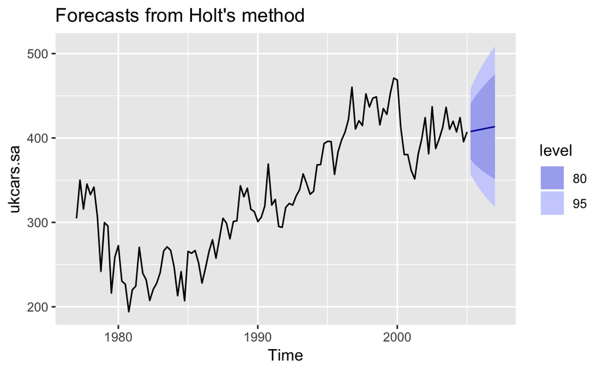

```r
autoplot(ukcars.holt)
```

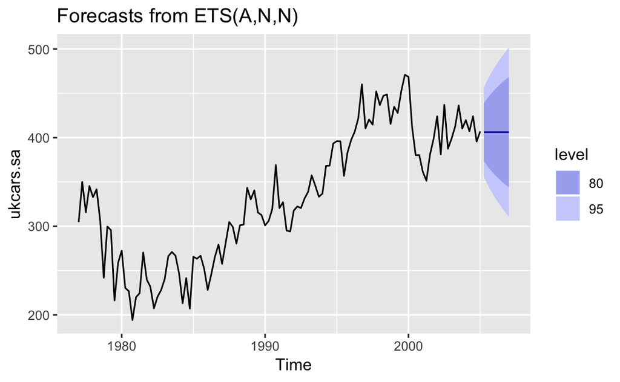

```r
ukcars.ets %>% forecast(h=8) %>% autoplot()
```

The model that seems to provide the most realistic forecasts is the additive damped trend method model (i.e., `stlf`), as the trend varies over the forecast periods, whereas the Holt linear and ETS (A,N,N) models are simply linear projections.

**10h.** Check the residuals of your preferred model.

```
    Ljung-Box test

data:  Residuals from STL +  ETS(A,Ad,N)
Q* = 24.138, df = 3, p-value = 2.337e-05

Model df: 5.   Total lags used: 8
```

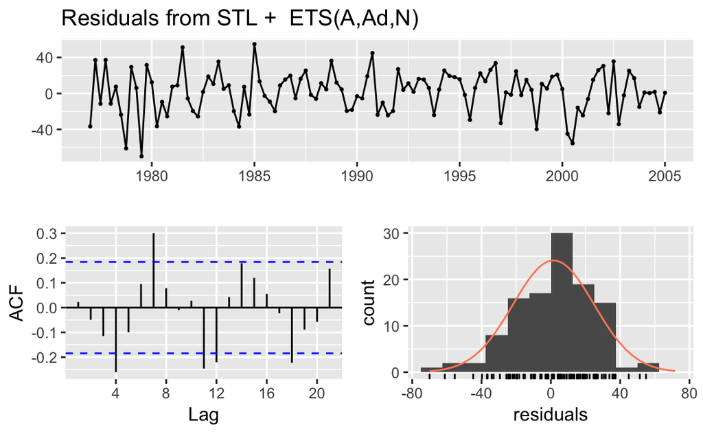

```r
checkresiduals(ukcars.stlf)
```

The low p-value from the Ljung-Box test indicates that there is possible autocorrelation in the first 8 lags.

#### 11. For this exercise use data set `visitors`, the monthly Australian short-term overseas visitors data, May 1985–April 2005.

**11a.** Make a time plot of your data and describe the main features of the series.

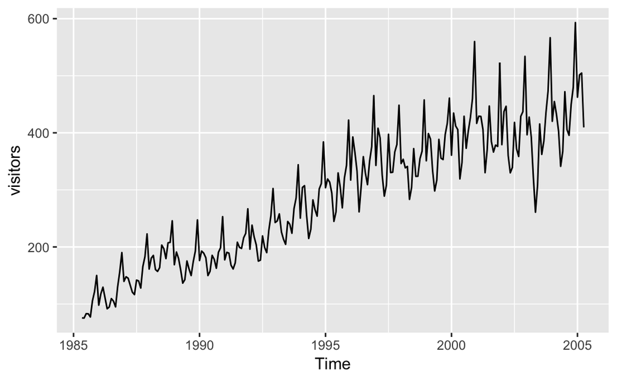

```r
autoplot(visitors)
```

The time series has positive trend and appears to have seasonality with increasing variance over time.

**11b.** Split your data into a training set and a test set comprising the last two years of available data. Forecast the test set using Holt-Winters’ multiplicative method.

```r
v.train <- window(visitors, end=c(2003,4))
v.test <- window(visitors, start=c(2003,5))
v.hw <- hw(v.train, seasonal="multiplicative")
fc.hw <- forecast(v.hw, h=24)
```

**11c.** Why is multiplicative seasonality necessary here?

It’s necessary because the seasonal variance is increasing over time.

**11d.** Forecast the two-year test set using each of the following methods:

**11di.** ETS model:

```r
v.ets <- ets(v.train)
fc.ets <- forecast(v.ets, h=24)
```

**11dii.** ETS model applied to a Box-Cox transformed series

```r
lambda <- BoxCox.lambda(v.train)
v.bc.ets <- ets(v.train, lambda = lambda)
fc.bc.ets <- forecast(v.bc.ets, h=24)
```

**11diii.** seasonal naive

```r
v.sn <- snaive(v.train)
fc.sn <- forecast(v.sn, h=24)
```

**11div.** STL decomposition applied to the Box-Cox transformed data followed by an ETS model applied to the seasonally adjusted (transformed) data.

```r
# Box-Cox transformation
v.bc <- BoxCox(v.train, lambda=lambda)
v.stl <- stl(v.bc, s.window="periodic")
# seasonally adjust transformed data
v.sa <- seasadj(v.stl)
# back-transform data
v.sa <- (lambda * v.sa + 1)^(1/lambda)
# build and forecast ETS model
v.sa.ets <- ets(v.sa, lambda=lambda)
fc.sa.ets <- forecast(v.sa.ets, h=24)
```

**11e.** Which method gives the best forecasts? Does it pass the residual tests?

```r
accuracy(fc.ets, v.test)
```

```
                     ME     RMSE      MAE        MPE      MAPE     MASE
Training set  0.7640074 14.53480 10.57657  0.1048224  3.994788 0.405423
Test set     72.1992664 80.23124 74.55285 15.9202832 16.822384 2.857773
                    ACF1 Theil's U
Training set -0.05311217        NA
Test set      0.58716982  1.127269
```

```r
accuracy(fc.bc.ets, v.test)
```

```
                    ME     RMSE      MAE        MPE      MAPE      MASE
Training set  1.001363 14.97096 10.82396  0.1609336  3.974215 0.4149057
Test set     69.458843 78.61032 72.41589 15.1662261 16.273089 2.7758586
                    ACF1 Theil's U
Training set -0.02535299        NA
Test set      0.67684148  1.086953
```

```r
accuracy(fc.sn, v.test)
```

```
                   ME     RMSE      MAE      MPE      MAPE     MASE
Training set 17.29363 31.15613 26.08775 7.192445 10.285961 1.000000
Test set     32.87083 50.30097 42.24583 6.640781  9.962647 1.619375
                  ACF1 Theil's U
Training set 0.6327669        NA
Test set     0.5725430 0.6594016
```

```r
accuracy(fc.sa.ets, v.test)
```

```
                     ME     RMSE      MAE         MPE      MAPE      MASE
Training set -0.3112065 14.52194 10.69322 -0.07967328  4.063192 0.4108385
Test set     46.1906462 82.00076 64.76930  8.19735098 14.508725 2.4884664
                   ACF1 Theil's U
Training set -0.0346289        NA
Test set      0.3601443  1.112587
```

```
    Ljung-Box test

data:  Residuals from Seasonal naive method
Q* = 295.02, df = 24, p-value < 2.2e-16

Model df: 0.   Total lags used: 24
```

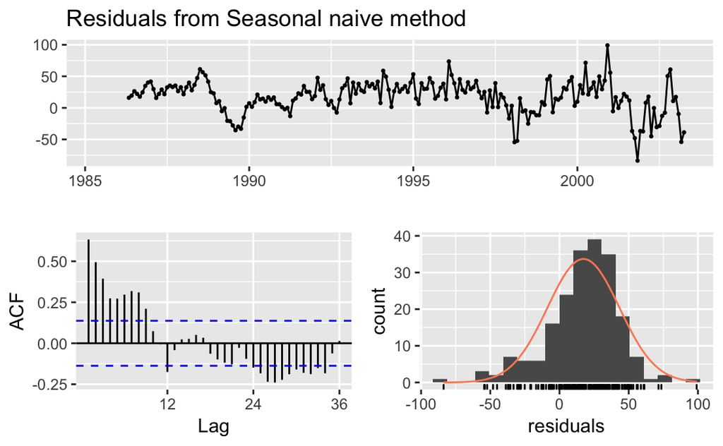

```r
checkresiduals(fc.sn)
```

The seasonal-naive model seems to do best, having the lowest RMSE - however, based on the low p-value from its Ljung-Box test and number of significant lags in the ACF plot, there is a high probability that the data is autocorrelated.

**11f.** Compare the same four methods using time series cross-validation with the `tsCV()` function instead of using a training and test set. Do you come to the same conclusions?

```r
func.ets <- function(y, h) { forecast(ets(y), h=h) }
cv.ets <- tsCV(visitors, func.ets, h=1)
sqrt(mean(cv.ets^2, na.rm=TRUE))
```

```
[1] 18.52985
```

```r
func.bc.ets <- function(y, h) { forecast(ets(y, lambda=lambda), h=h) }
cv.bc.ets <- tsCV(visitors, func.bc.ets, h=1)
sqrt(mean(cv.bc.ets^2, na.rm=TRUE))
```

```
[1] 21.94145
```

```r
cv.sn <- tsCV(visitors, snaive, h=1)
sqrt(mean(cv.sn^2, na.rm=TRUE))
```

```
[1] 32.62379
```

```r
func.sa.ets <- function(y, h) {
  l <- BoxCox.lambda(y)
  bc <- BoxCox(y, lambda=l)
  bc.stl <- stl(bc, s.window="periodic")
  bc.sa <- seasadj(bc.stl)
  bt.sa <- (l * bc.sa + 1)^(1/l)
  sa.ets <- ets(bt.sa, lambda=l)
  forecast(sa.ets, h=h)
}
cv.sa.ets <- tsCV(visitors, func.sa.ets, h=1)
sqrt(mean(cv.sa.ets^2, na.rm=TRUE))
```

```
[1] 43.63903
```

Using time-series cross-validation, the method with the lowest RMSE was the basic ETS (MAM) model.

#### 12. The `fets()` function below returns ETS forecasts.

```r
fets <- function(y, h) {
  forecast(ets(y), h = h)
}
```

**12a.** Apply `tsCV()` for a forecast horizon of $h$ = 4 for both ETS and seasonal naïve methods to the `qcement` data, (Hint: use the newly created `fets()` and the existing `snaive()` functions as your forecast function arguments.)

```r
cv.ets <- tsCV(qcement, fets, h=4)
cv.snaive <- tsCV(qcement, snaive, h=4)
sqrt(mean(cv.ets^2, na.rm=TRUE))
```

```
[1] 0.111846
```

```r
sqrt(mean(cv.snaive^2, na.rm=TRUE))
```

```
[1] 0.134447
```

The RMSE was a bit lower (and thus better) for the time-series cross-validated ETS model.

**12b.** Compute the MSE of the resulting 4-step-ahead errors. (Hint: make sure you remove missing values.) Why are there missing values? Comment on which forecasts are more accurate. Is this what you expected?

```r
mean(cv.ets^2, na.rm=TRUE)
```

```
[1] 0.01250954
```

```r
mean(cv.snaive^2, na.rm=TRUE)
```

```
[1] 0.01807599
```

There are missing values because modeling with time-series cross-validation produces *forecasts* that are just fitted values of the dataset. According to the MSEs, forecasts from the ETS model were more accurate, which is what I expected, as its RMSE was lower than that of the seasonal-naive model and because ETS is fundamentally more nuanced than a seasonal naive model. ETS takes into account all past observations and weights them relative to the present. Seasonal naive, however, *naively* weights each season the same.

#### 13. Compare `ets()`, `snaive()` and `stlf()` on the following six time series. For `stlf()`, you might need to use a Box-Cox transformation. Use a test set of three years to decide what gives the best forecasts. `ausbeer`, `bricksq`, `dole`, `a10`, `h02`, `usmelec`.

```r
frequency(ausbeer)
```

```
[1] 4
```

```r
beer.train <- window(ausbeer, end=c(2006,4))
beer.test <- window(ausbeer, start=c(2007,1))
length(beer.test)
```

```
[1] 14
```

```r
beer.ets <- ets(beer.train)
beer.ets.fc <- forecast(beer.ets, h=14)
beer.ets.acc <- data.frame(accuracy(beer.ets.fc, beer.test))
```

```r
beer.snaive.fc <- snaive(beer.train, h=14)
beer.snaive.acc <- data.frame(accuracy(beer.snaive.fc, beer.test))
```

```r
#beer.lambda <- BoxCox.lambda(beer.train)
beer.stlf.fc <- stlf(beer.train, h=14)
beer.stlf.acc <- data.frame(accuracy(beer.stlf.fc, beer.test))
```

```r
beer.ets.acc$RMSE[2]
```

```
[1] 9.351618
```

```r
beer.snaive.acc$RMSE[2]
```

```
[1] 13.48809
```

```r
beer.stlf.acc$RMSE[2]
```

```
[1] 10.54399
```

```r
frequency(bricksq)
```

```
[1] 4
```

```r
bricks.train <- window(bricksq, end=c(1991,4))
bricks.test <- window(bricksq, start=c(1992,1))
length(bricks.test)
```

```
[1] 11
```

```r
bricks.ets <- ets(bricks.train)
bricks.ets.fc <- forecast(bricks.ets, h=11)
bricks.ets.acc <- data.frame(accuracy(bricks.ets.fc, bricks.test))
```

```r
bricks.snaive.fc <- snaive(bricks.train, h=11)
bricks.snaive.acc <- data.frame(accuracy(bricks.snaive.fc, bricks.test))
```

```r
bricks.lambda <- BoxCox.lambda(bricks.train)
bricks.stlf.fc <- stlf(bricks.train, lambda=bricks.lambda, h=11)
bricks.stlf.acc <- data.frame(accuracy(bricks.stlf.fc, bricks.test))
```

```r
bricks.ets.acc$RMSE[2]
```

```
[1] 22.82349
```

```r
bricks.snaive.acc$RMSE[2]
```

```
[1] 35.73132
```

```r
bricks.stlf.acc$RMSE[2]
```

```
[1] 22.89131
```

The forecast model with the lowest RMSE is still the ETS model, but only by a fraction of a point.

```r
frequency(dole)
```

```
[1] 12
```

```r
dole.train <- window(dole, end=c(1989,12))
dole.test <- window(dole, start=c(1990,1))
length(dole.test)
```

```
[1] 31
```

```r
dole.ets <- ets(dole.train)
dole.ets.fc <- forecast(dole.ets, h=31)
dole.ets.acc <- data.frame(accuracy(dole.ets.fc, dole.test))
```

```r
dole.snaive.fc <- snaive(dole.train, h=31)
dole.snaive.acc <- data.frame(accuracy(dole.snaive.fc, dole.test))
```

```r
dole.lambda <- BoxCox.lambda(dole.train)
dole.stlf.fc <- stlf(dole.train, lambda=dole.lambda, h=31)
dole.stlf.acc <- data.frame(accuracy(dole.stlf.fc, dole.test))
```

```r
dole.ets.acc$RMSE[2]
```

```
[1] 247199.3
```

```r
dole.snaive.acc$RMSE[2]
```

```
[1] 273680
```

```r
dole.stlf.acc$RMSE[2]
```

```
[1] 289248.7
```

All models performed poorly, but the one with the lowest RMSE was again the ETS model.

```r
frequency(usmelec)
```

```
[1] 12
```

```r
elec.train <- window(usmelec, end=c(2010,12))
elec.test <- window(usmelec, start=c(2011,1))
length(elec.test)
```

```
[1] 30
```

```r
elec.ets <- ets(elec.train)
elec.ets.fc <- forecast(elec.ets, h=30)
elec.ets.acc <- data.frame(accuracy(elec.ets.fc, elec.test))
```

```r
elec.snaive.fc <- snaive(elec.train, h=30)
elec.snaive.acc <- data.frame(accuracy(elec.snaive.fc, elec.test))
```

```r
elec.lambda <- BoxCox.lambda(elec.train)
elec.stlf.fc <- stlf(elec.train, lambda=elec.lambda, h=30)
elec.stlf.acc <- data.frame(accuracy(elec.stlf.fc, elec.test))
```

```r
elec.ets.acc$RMSE[2]
```

```
[1] 16.15658
```

```r
elec.snaive.acc$RMSE[2]
```

```
[1] 11.79623
```

```r
elec.stlf.acc$RMSE[2]
```

```
[1] 23.09123
```

In the case of `uselec`, the forecast model that performed the best was the seasonal-naive model.

#### 14. Use `ets()` on the following series: `bicoal`, `chicken`, `dole`, `usdeaths`, `lynx`, `ibmclose`, `eggs`.

```r
par(mfrow=c(3,3))
plot(bicoal)
plot(chicken)
```

```r
plot(dole)
plot(usdeaths)
```

```r
plot(lynx)
plot(ibmclose)
```

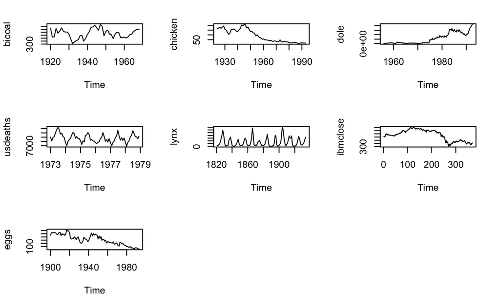

```r
plot(eggs)
```

**14a.** Does it always give good forecasts?

```r
bicoal.train <- window(bicoal, end=1958)
bicoal.test <- window(bicoal, start=1959)
bicoal.ets <- ets(bicoal.train)
bicoal.fc <- forecast(bicoal.ets, h=10)
bicoal.acc <- data.frame(accuracy(bicoal.fc, bicoal.test))
```

```r
chicken.train <- window(chicken, end=1983)
chicken.test <- window(chicken, start=1984)
chicken.ets <- ets(chicken.train)
chicken.fc <- forecast(chicken.ets, h=10)
chicken.acc <- data.frame(accuracy(chicken.fc, chicken.test))
```

```r
dole.train <- window(dole, end=c(1990,12))
dole.test <- window(dole, start=c(1991,1))
dole.ets <- ets(dole.train)
dole.fc <- forecast(dole.ets, h=19)
dole.acc <- data.frame(accuracy(dole.fc, dole.test))
```

```r
usdeaths.train <- window(usdeaths, end=c(1977,12))
usdeaths.test <- window(usdeaths, start=c(1978,1))
usdeaths.ets <- ets(usdeaths.train)
usdeaths.fc <- forecast(usdeaths.ets, h=12)
usdeaths.acc <- data.frame(accuracy(usdeaths.fc, usdeaths.test))
```

```r
lynx.train <- window(lynx, end=1924)
lynx.test <- window(lynx, start=1925)
lynx.ets <- ets(lynx.train)
lynx.fc <- forecast(lynx.ets, h=10)
lynx.acc <- data.frame(accuracy(lynx.fc, lynx.test))
```

```r
ibmclose.train <- window(ibmclose, end=358)
ibmclose.test <- window(ibmclose, start=359)
ibmclose.ets <- ets(ibmclose.train)
ibmclose.fc <- forecast(ibmclose.ets, h=10)
ibmclose.acc <- data.frame(accuracy(ibmclose.fc, ibmclose.test))
```

```r
eggs.train <- window(eggs, end=1983)
eggs.test <- window(eggs, start=1984)
eggs.ets <- ets(eggs.train)
eggs.fc <- forecast(eggs.ets, h=10)
eggs.acc <- data.frame(accuracy(eggs.fc, eggs.test))
```

```r
paste("bicoal: ", round(coal.acc$MAPE[2],1), "%", sep="")
```

[output not shown]

```r
paste("chicken: ", round(chicken.acc$MAPE[2],1), "%", sep="")
```

```
[1] "chicken: 21.4%"
```

```r
paste("dole: ", round(dole.acc$MAPE[2],1), "%", sep="")
```

```
[1] "dole: 7.3%"
```

```r
paste("usdeaths: ", round(usdeaths.acc$MAPE[2],1), "%", sep="")
```

```
[1] "usdeaths: 2.7%"
```

```r
paste("lynx: ", round(lynx.acc$MAPE[2],1), "%", sep="")
```

```
[1] "lynx: 136.9%"
```

```r
paste("ibmclose: ", round(ibmclose.acc$MAPE[2],1), "%", sep="")
```

```
[1] "ibmclose: 3.7%"
```

```r
paste("eggs: ", round(eggs.acc$MAPE[2],1), "%", sep="")
```

```
[1] "eggs: 22.4%"
```

Because the models are based on different datasets, it’s best to compare their performance using an error measure that is relative, like mean absolute percentage error (MAPE). So, when comparing MAPE, the `ets` function does not always provide good forecasts.

**14b.** Find an example where it does not work well. Can you figure out why?

The ETS model with the worst MAPE was the one for the `lynx` dataset, with a MAPE of 136.9%.

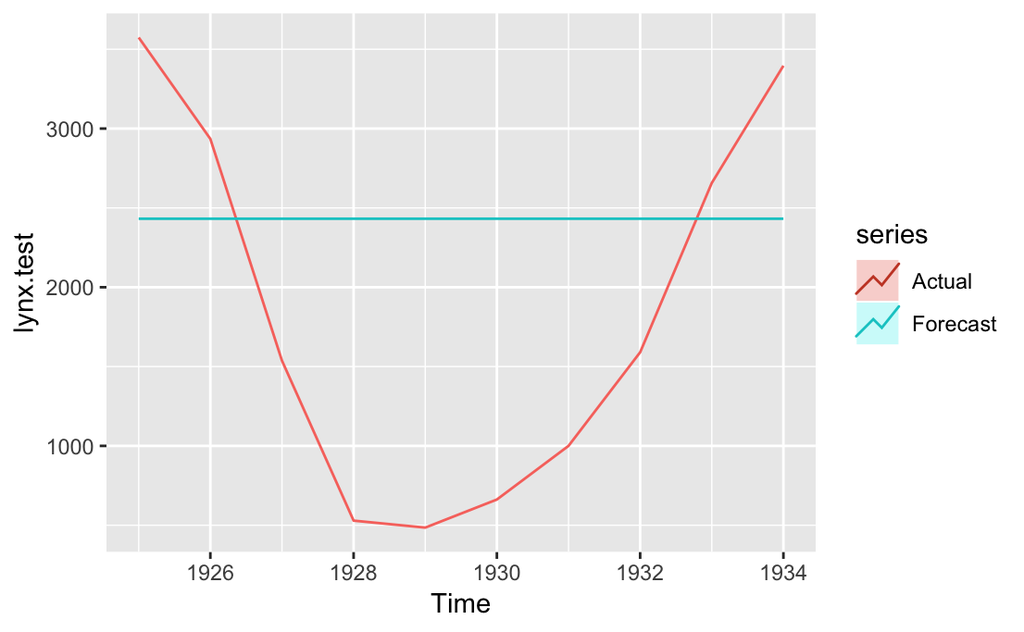

```r
autoplot(lynx.test, series="Actual") + autolayer(lynx.fc, series="Forecast", PI=FALSE)
```

As seen in this plot, the forecast trend is a straight line, whereas the actual data is parabolic.

```r
frequency(lynx)
```

```
[1] 1
```

As the `lynx` dataset is only annual data (i.e., one data point per year), it has no seasonality, so the `ets` model cannot function properly.

#### 15. Show that the point forecasts from an ETS(M,A,M) model are the same as those obtained using Holt-Winters’ multiplicative method.

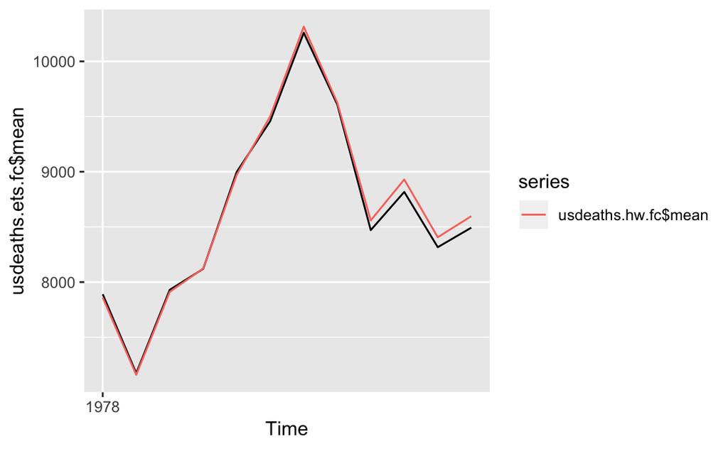

```r
usdeaths.ets <- ets(usdeaths.train, model="MAM")
usdeaths.ets.fc <- forecast(usdeaths.ets, h=12)
usdeaths.hw.fc <- hw(usdeaths.train, seasonal = "multiplicative", h=12)
autoplot(usdeaths.ets.fc$mean) + autolayer(usdeaths.hw.fc$mean)
```

As seen in the plot comparing the forecasts from the two models, the point forecasts are very similar.

#### 16. Show that the forecast variance for an ETS(A,N,N) model is given by

$\sigma^2[1+\alpha^2(h-1)]$

How about I don’t?

#### 17. Write down 95% prediction intervals for an ETS(A,N,N) model as a function of $l_T$, $\alpha$, $h$, and $\sigma$, assuming Gaussian errors.

As a prediction interval can be written as: